# Lab 08 - Text Mining

Shih-Ting (Cindy) Huang

```r
knitr::opts_chunk$set(eval = T, warning=F, echo=F)
```

# Learning goals

- Use `unnest_tokens()` and `unnest_ngrams()` to extract tokens and ngrams from text.
- Use dplyr and ggplot2 to analyze text data

# Lab description

For this lab we will be working with the medical record transcriptions from https://www.mtsamples.com/. And is loaded and “fairly” cleaned at https://github.com/JSC370/jsc370-2022/blob/main/data/medical_transcriptions/mtsamples.csv.

This markdown document should be rendered using `github_document` document.

### Setup packages

You should load in `dplyr`, (or `data.table` if you want to work that way), `ggplot2` and `tidytext`. If you don’t already have `tidytext` then you can install with

### read in Medical Transcriptions

Loading in reference transcription samples from https://www.mtsamples.com/

```
## # A tibble: 6 x 3
##   description                                     medical_special~ transcription
##   <chr>                                           <chr>            <chr>
## 1 A 23-year-old white female presents with compl~ Allergy / Immun~ "SUBJECTIVE:~
## 2 Consult for laparoscopic gastric bypass.        Bariatrics       "PAST MEDICA~
## 3 Consult for laparoscopic gastric bypass.        Bariatrics       "HISTORY OF ~
## 4 2-D M-Mode. Doppler.                            Cardiovascular ~ "2-D M-MODE:~
## 5 2-D Echocardiogram                              Cardiovascular ~ "1.  The lef~
## 6 Morbid obesity.  Laparoscopic antecolic antega~ Bariatrics       "PREOPERATIV~
```

## Question 1: What specialties do we have?

We can use `count()` from `dplyr` to figure out how many different categories do we have? Are these categories related? overlapping? evenly distributed?

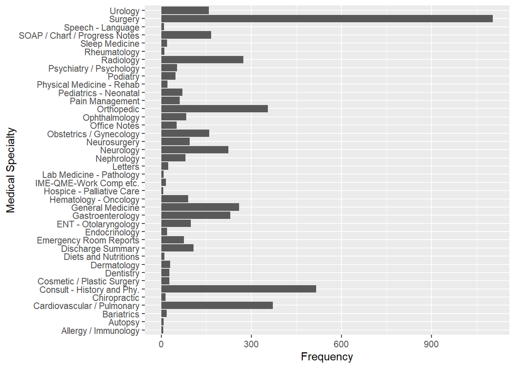

## Question 2

- Tokenize the the words in the `transcription` column
- Count the number of times each token appears
- Visualize the top 20 most frequent words

Explain what we see from this result. Does it makes sense? What insights (if any) do we get?

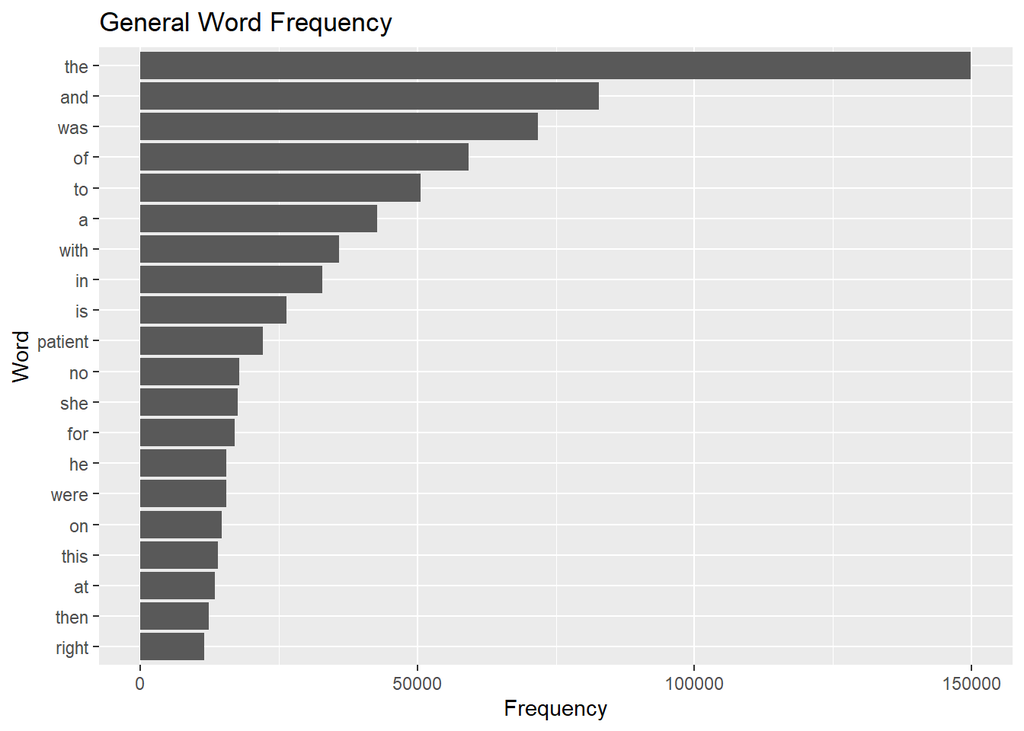

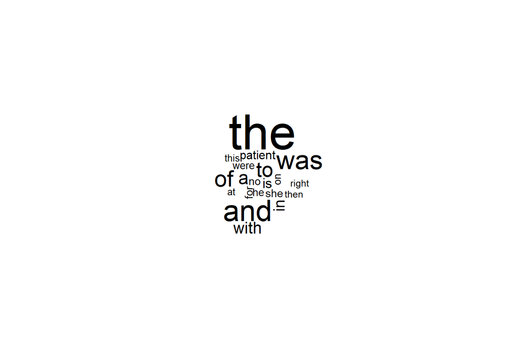

- We don’t get a lot of meanignful insights from the results shown above because we have included stopwords (ex. “the”, “and”, “of”, etc.), which appear the most common in the corpus.

## Question 3

- Redo visualization but remove stopwords before
- Bonus points if you remove numbers as well

What do we see know that we have removed stop words? Does it give us a better idea of what the text is about?

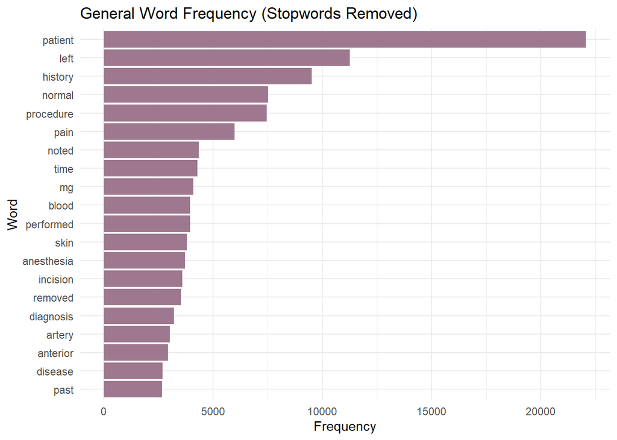

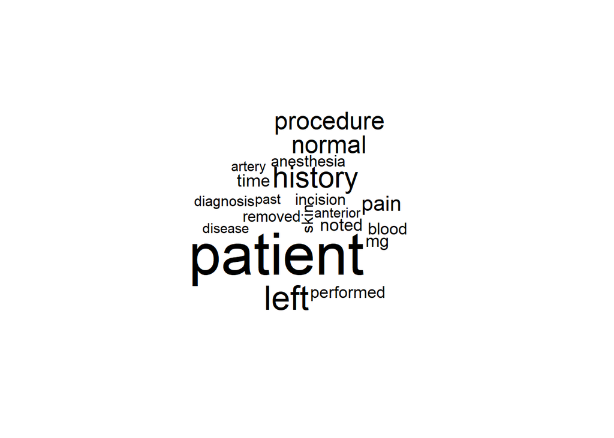

# Question 4

Repeat question 2, but this time tokenize into bi-grams. How does the result change if you look at tri-grams?

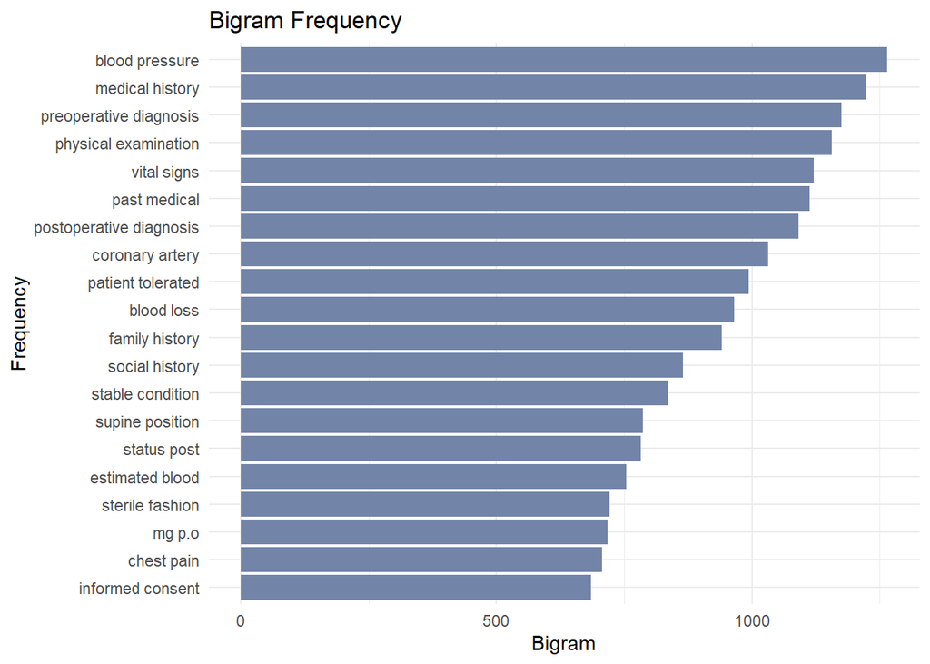

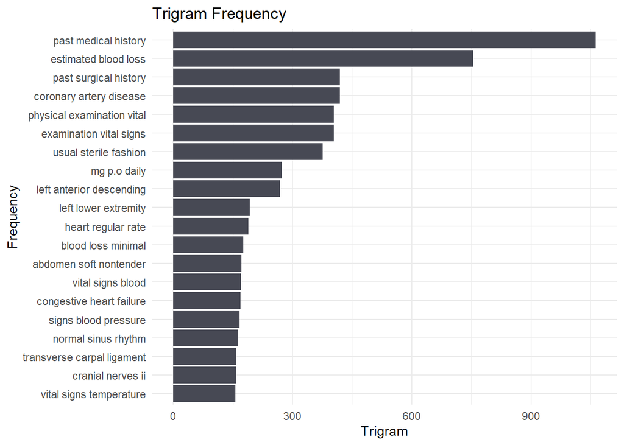

# Question 5

Using the results you got from question 4. Pick a word and count the words that appears after and before it.

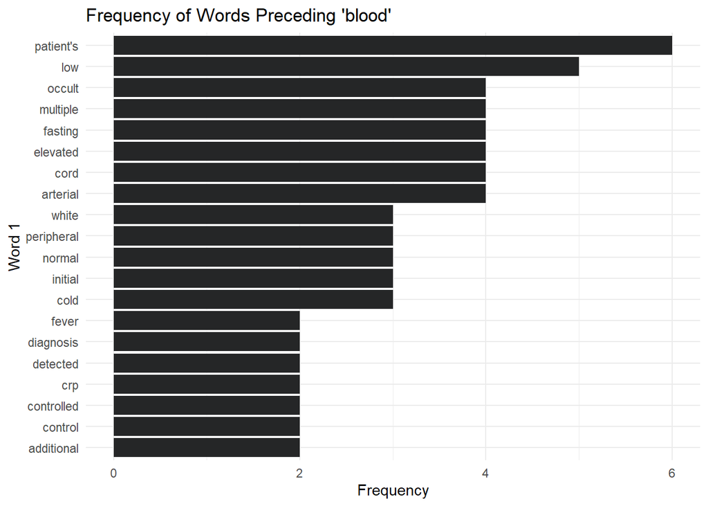

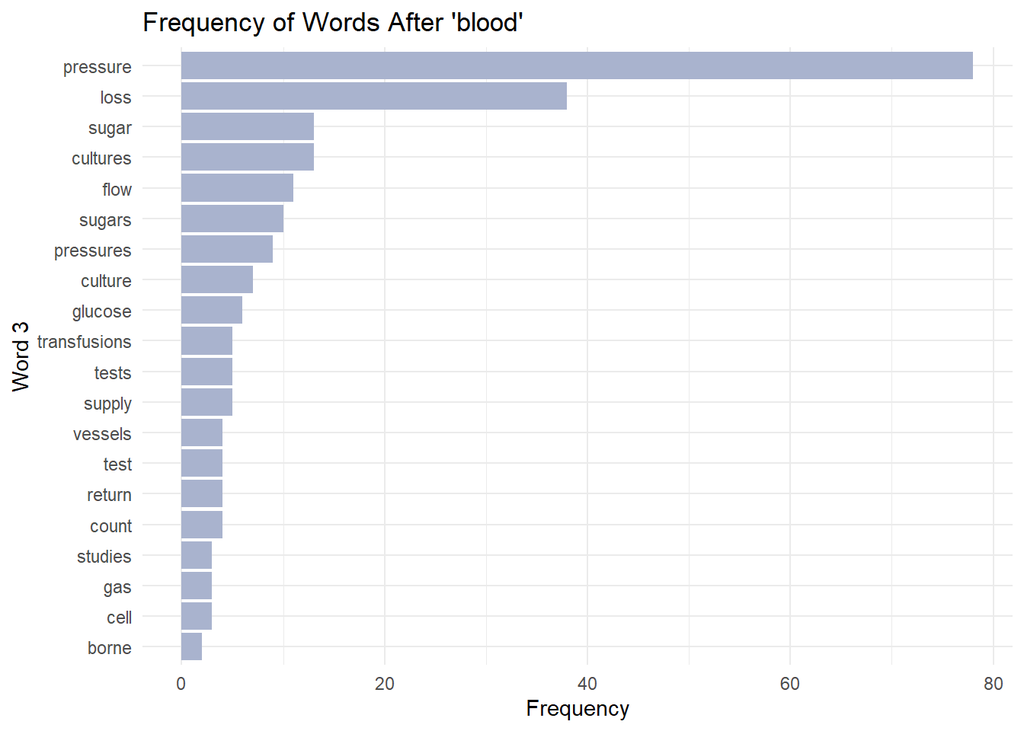

# Question 6

Which words are most used in each of the specialties. you can use `group_by()` and `top_n()` from `dplyr` to have the calculations be done within each specialty. Remember to remove stopwords. How about the most 5 used words?

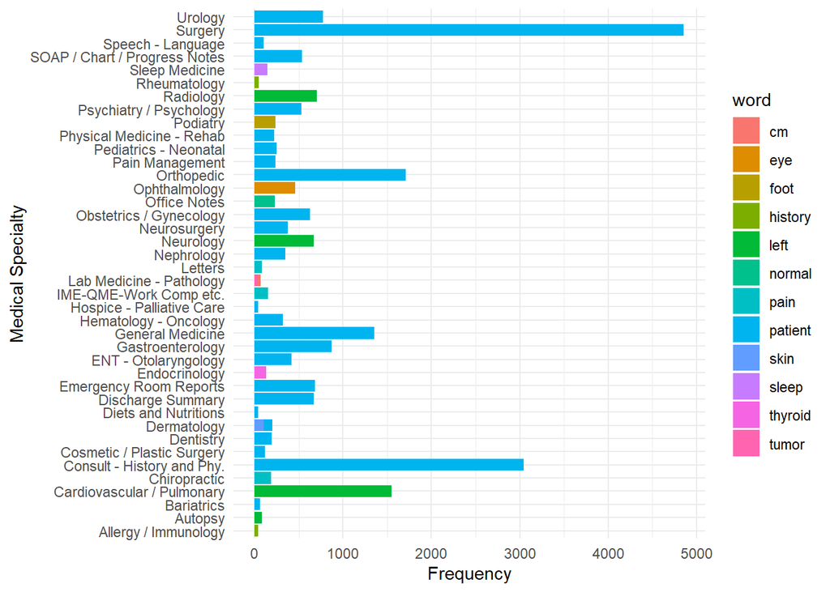

# Question 7 - extra

Find your own insight in the data:

Ideas:

- Interesting ngrams
- See if certain words are used more in some specialties then others

```
## # A tibble: 6 x 3
## # Groups:   word [2]
##   word    medical_specialty          word_frequency
##   <chr>   <chr>                               <int>
## 1 patient Surgery                              4855
## 2 patient Consult - History and Phy.           3046
## 3 patient Orthopedic                           1711
## 4 patient Cardiovascular / Pulmonary           1516
## 5 patient General Medicine                     1356
## 6 pain    Consult - History and Phy.           1153
```

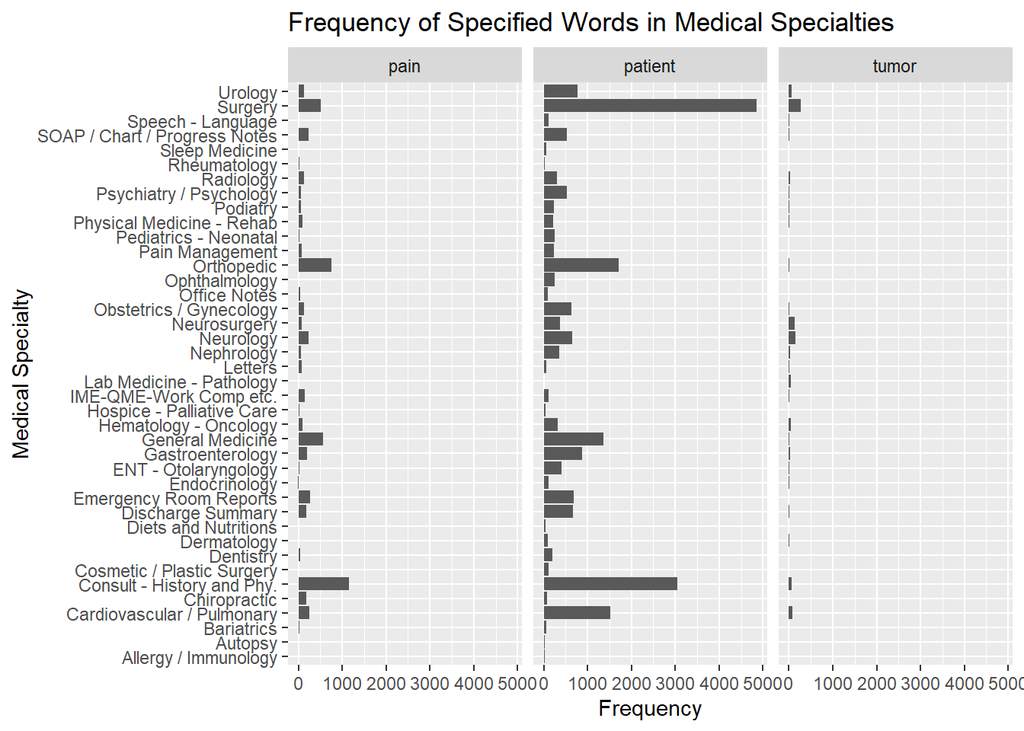

Looking specifically at the words “pain”, “patient”, and “tumor”, we observer that the surgery category has the most mentions of “patient” and “tumor”, whereas the consulting category has the most mentions of “pain”.

# Deliverables

1. Questions 1-7 answered, pdf or html output uploaded to quercus